# Análisis de procesos puntuales para actividad comercial en Medellín

Julian Castaño Pineda - Luisa Henao Vargas

2024-09-25

```r
library(tidyverse)
library(sf)
library(mapview)
library(spatstat)
```

# Pregunta de Investigación

¿Cuál es la distribución espacial de la apertura de une establecimiento comercial de bebidas alcohólicas y tabaco en la ciudad de Medellín, y cómo puede esta información guiar la ubicación estratégica de nuevos establecimientos en función de la demanda potencial?

El objetivo de este estudio es analizar la distribución de licoreras y cigarrerías georreferenciadas, explorando e identificando posibles patrones y áreas de alta concentración, para proporcionar recomendaciones sobre la ubicación estratégica de nuevos negocios en función de la competencia, la demanda del mercado y las características sociodemográficas de la zona.

Esto permite no solo entender la distribución actual, sino también ofrecer información valiosa para la toma de decisiones empresariales.

# Datos

Los datos fueron obtenidos de: https://www.medellin.gov.co/geomedellin/datosAbiertos/1024

**Establecimientos de Industria y Comercio** de los contribuyentes inscritos en el Registro de información tributaria (RIT) georreferenciados, con el tipo de actividad económica desarrollada por el contribuyente. Se actualiza en línea con la inscripción, cancelación o actualización de los establecimientos en el sistema de información de la subsecretaría.

```r
# Ver estructura de los datos
class(pp_data)
class(medellin)
str(pp_data)
str(medellin)
```

```r
pp_data <- pp_data %>% filter(nombre_establecimiento != "NO POSEE ESTABLECIMIENTOS")
```

# Visualización datos

## Mapa por ciuu barrios y comunas

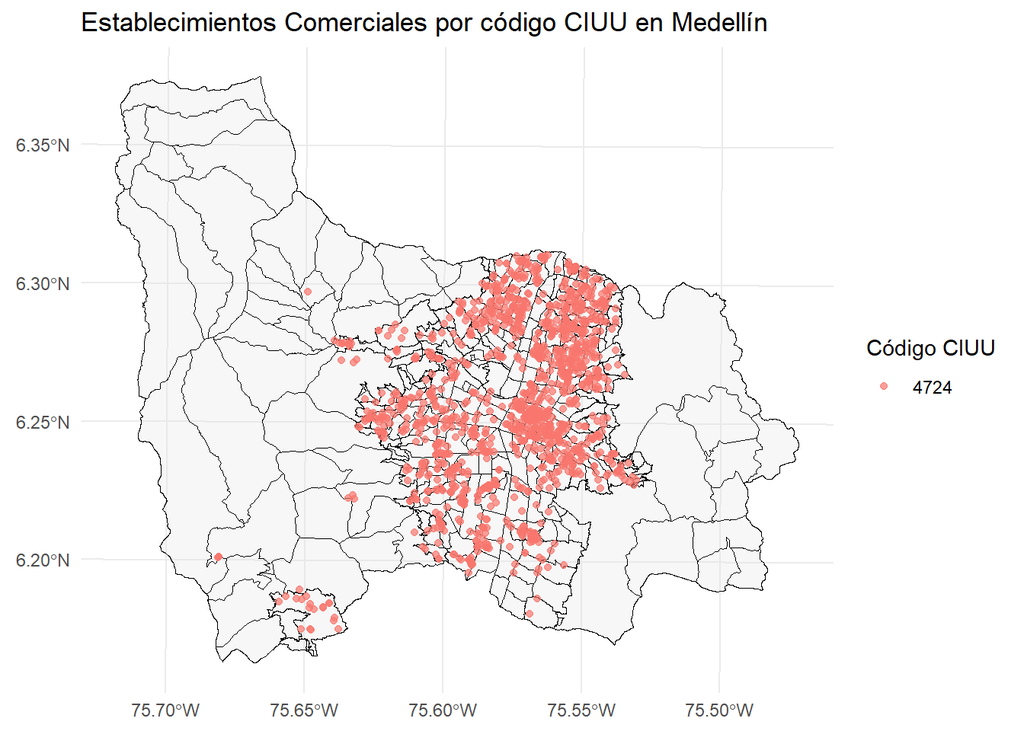

```r
codigos = pp_data$codigociiu %>% unique() %>% sort()
codigo_ciiu = 4741
codigo_ciiu = codigos[344]
comercios_min <- pp_data %>% filter(codigociiu == codigo_ciiu)
# Graficar Medellín coloreando los barrios y superponiendo los puntos de los establecimientos
ggplot() +
  geom_sf(data = medellin, color = "black", alpha = 0.3) +  # Colorear los barrios
  geom_sf(data = comercios_min, aes(color = codigociiu), alpha = 0.7) +  # Superponer los puntos
  labs(title = "Establecimientos Comerciales por código CIUU en Medellín", fill = "Barrios", color = "Código CIUU") +
  theme_minimal()
```

## Mapa solo barrios

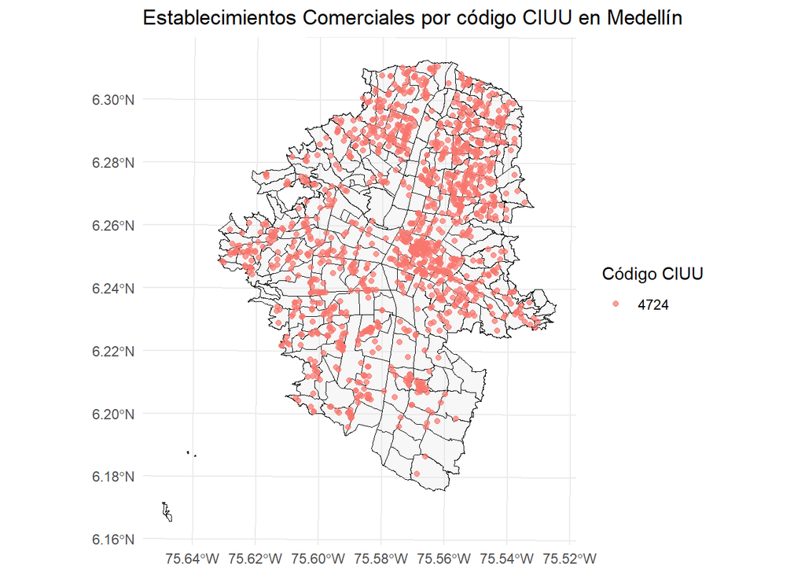

```r
codigos = pp_data$codigociiu %>% unique() %>% sort()
codigo_ciiu = 4741
codigo_ciiu = codigos[344]
comercios_min <- pp_data %>% filter(codigociiu == codigo_ciiu)

medellin_b <- medellin %>% filter(subtipo_barriovereda == 1)


points_intersect <- lengths(st_intersects(comercios_min, medellin_b)) > 0
comercios_min_b <- comercios_min[points_intersect, ]

# Graficar Medellín coloreando los barrios y superponiendo los puntos de los establecimientos
ggplot() +
  geom_sf(data = medellin_b, color = "black", alpha = 0.3) +  # Colorear los barrios
  geom_sf(data= comercios_min_b, aes(color = codigociiu), alpha = 0.7) +  # Superponer los puntos
  labs(title = "Establecimientos Comerciales por código CIUU en Medellín", color = "Código CIUU") +
  theme_minimal()
```

## Mapa interactivo (mapview)

```r
mapview(comercios_min_b,
  zcol = "comuna",
  label = comercios_min_b$nombre_establecimiento,
  legend = TRUE
)
```

[interactive chart not shown]

# Creación de objetos ppp

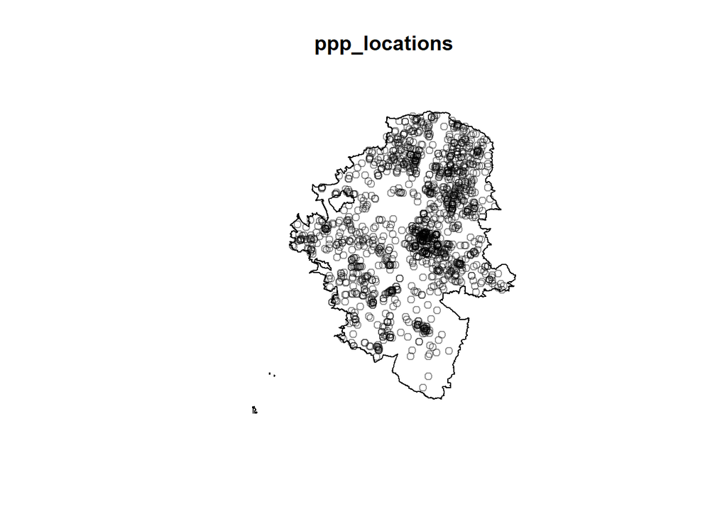

```r
win <- as.owin(medellin_b)

ppp_locations <- ppp(
  x = st_coordinates(comercios_min_b)[, 1],
  y = st_coordinates(comercios_min_b)[, 2],
  window = win
)

unitname(ppp_locations) <- "meters"

ppp_locations <- as.ppp(ppp_locations)

koords = c(2241000, 2257000)
ppp_locations$window$yrange = koords

plot(ppp_locations)
```

# Pruebas de cuadratura

quadratcount: Divide el área de Medellín en una cuadrícula de 3x4 para contar el número de puntos en cada cuadrante. quadrat.test: Realiza una prueba de Chi-cuadrado para evaluar si la distribución espacial es aleatoria o no.

Si los datos rechazan la hipótesis de aleatoriedad espacial se puede decir que los datos tienen una estructura espacial bien sea de cluster o inhibitoria.

## Plot

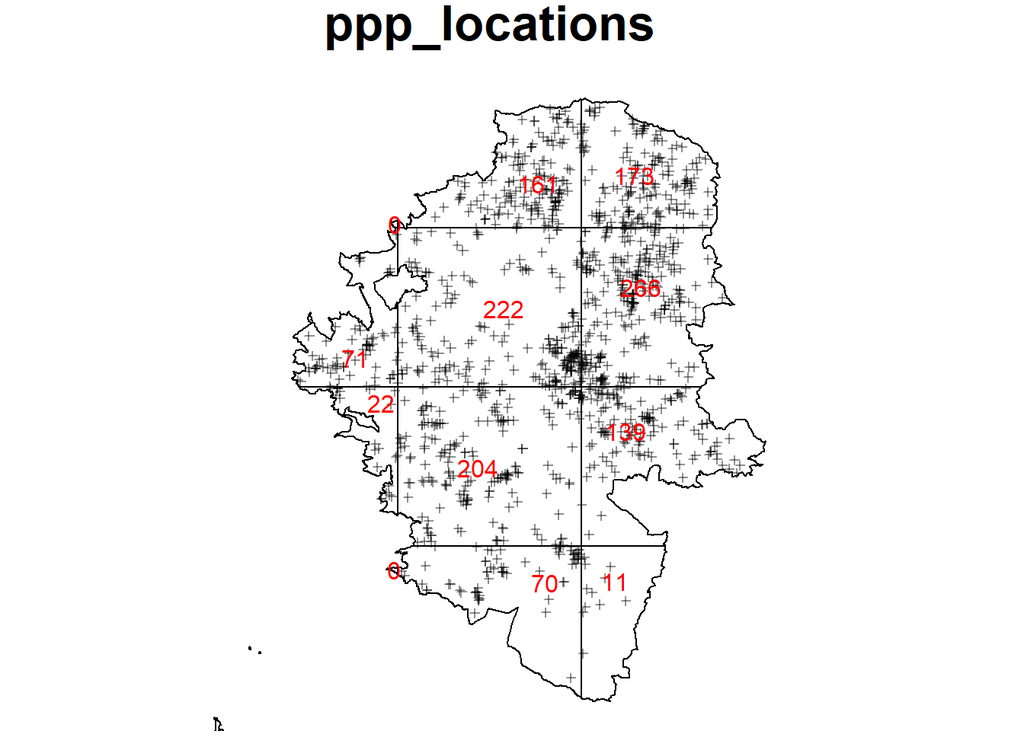

```r
par(mar = c(0, 0, 1.5, 1.5),
    cex.main = 2)

qc_locations <- quadratcount(ppp_locations, nx = 3, ny = 4)
plot(ppp_locations, pch = 3, cex = 0.6)
plot(qc_locations, add = TRUE, textargs = list(col = "red"))
```

## Test

```r
quadrat.test(qc_locations)
```

```
##
##  Chi-squared test of CSR using quadrat counts
##
## data:
## X2 = 194.24, df = 11, p-value < 2.2e-16
## alternative hypothesis: two.sided
##
## Quadrats: 12 tiles (irregular windows)
```

# Estimación de la intensidad del proceso

Estimación por suavizado Kernel:

$$\hat{\lambda}(x) = \frac{1}{h^2}
\sum_{i=1}^{n} \frac{\kappa\left(\frac{\|x -
x_i\|}{h}\right)}{q\left(\|x\|\right)}$$

Se calcularon 2 tipos de kernel. Kernel gaussiano y un kernel quartic.

**1. Kernel cuártico (o biweight kernel):**

$$K(u) = \frac{15}{16}(1 - u^2)^2 \quad
\text{para} \quad |u| \leq 1$$

$$K(u) = 0 \quad \text{para} \quad |u|
> 1$$

**2. Kernel gaussiano:**

$$K(u) = \frac{1}{\sqrt{2\pi}}
\exp\left(-\frac{u^2}{2}\right)$$

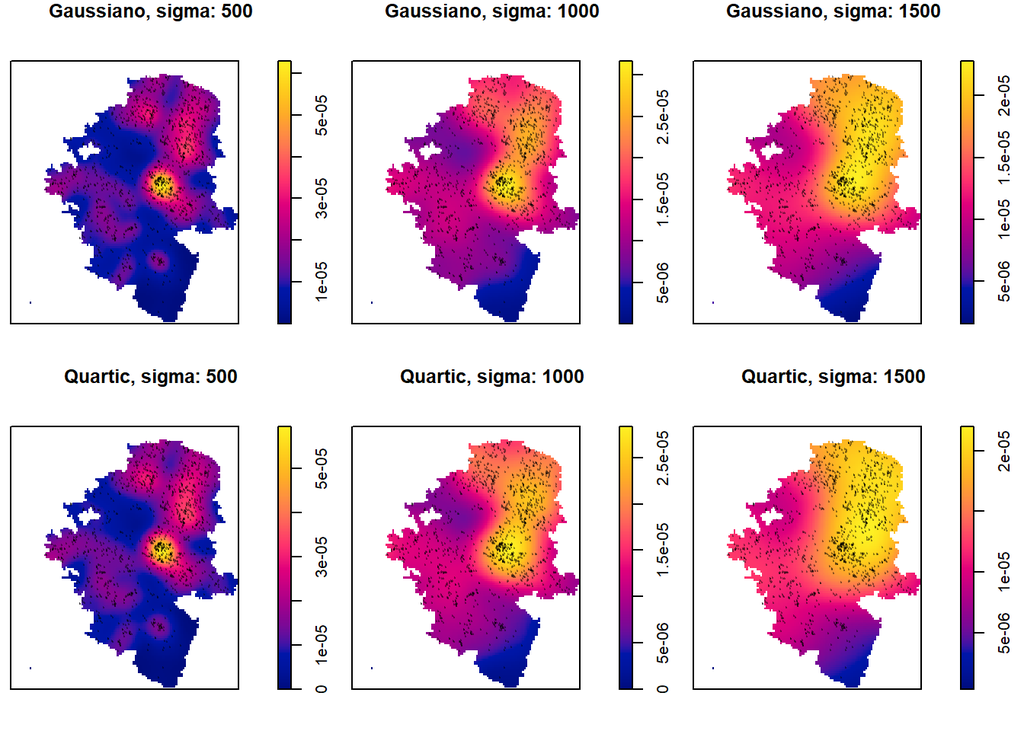

```r
par(mfrow = c(2, 3), mar = c(0, 0, 1, 2))
sigma <- c(500, 1000, 1500)
main <- c("Gaussiano","Quartic")
kernels <- c("gaussian","quartic")
for (i in 1:2) {
  for (j in 1:3) {
    ds <- density.ppp(ppp_locations, sigma = sigma[j], kernel = kernels[i])
    plot(ds,
      main = paste0(main[i], ", sigma: ", sigma[j])
    )
    plot(ppp_locations, add = TRUE, cex = 0.01, regular = FALSE)
  }
}
```